# Про размеры

Вадим Хайтов

24 марта 2019 г

Про размеры. Витает в воздухе идея, что размеры играют роль в том как работает морфотип. Давай посмотрим на первичку-первичку. На рисунках ниже приведены графики, где по оси ОХ отложена длина мидии, а по оси ОУ – вероятность правильного определения (переменная congr, которая принимает значения 1 если T = MT или E = ME, 0 если T = ME или E = MT). На всякий случай, то что ранее показывала Юля, имеет отношение к к моделям, описывающим связь вероятности встретить Т-морфотип (переменная “ind”) с набором предикторов.

На рисунках ниже приводятся логистическе кривые, описывающие связь между вероятностью встретить правильное определение (congr = 1) и размером мидии. Серые области - это доверительные интервалы. Точки - это отдельные мидии, по которым подобраны логистические кривые (добавлена небольшая случайная величина, чтобы убрать оверплоттнг).

На всякий случай: если можно провести горизонтальную линию, не вылезая за пределы доверительного интервала, то связь статистически не значимая. **NB!** На самом деле, интервалы должны быть заметно шире из-за множественности сравнений. Ну пока закроем глаза…

Остальные предикторы намеренно не включаю в анализ, чтобы показать, на максимально сыром материале, что связь с размерами несколько преувеличена.

Итак.

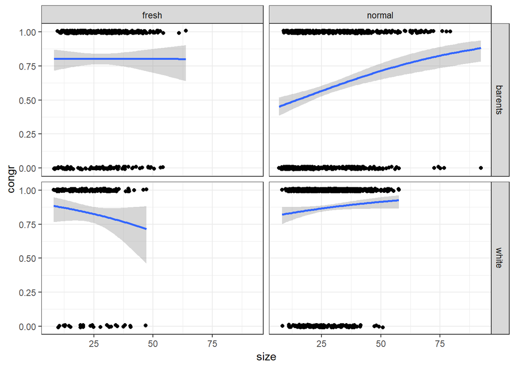

Итого, что-то подозрительное есть особенно в случае с barents-normal.

Посмотрим на отдельные популяции. Для более жесткого контроля здесь еще будем учитывать морфотип и подберем логистические кривые разные для разных морфотипов.

В barents-normal. Видно, что в двух популяциях “banka” и “ustie_sub” какая-то херня. Эти график показывают, что в данных двух популяциях вероятность правильного определения высока у любых мидий если они имеют Е морфотип. Однако у мидий имеющих Т-морфотип вероятность правильного определения низка у мелких мидий, но у крупных она выше. То есть у мелких мидий почему-то вдруг и только в этих двух популяциях морфотип перестал работать.

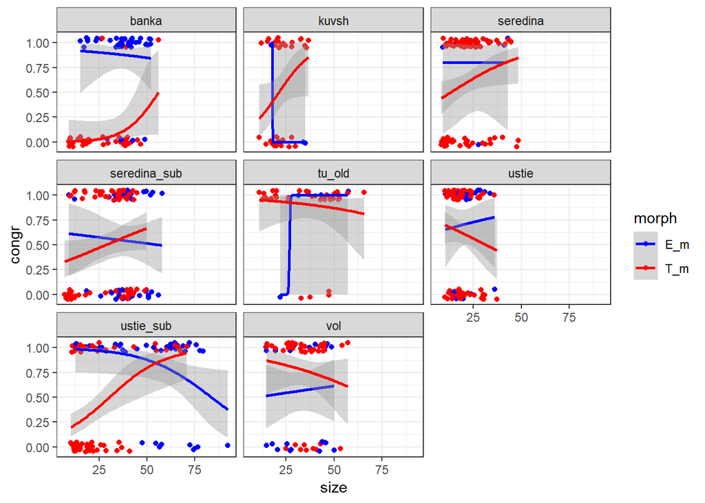

В barents-fresh. Здесь есть тоже какая-то странность в популяции “sevsk”, где вероятность правильного определения была низка среди мелких мидий, но уже Е-морфотипа (в популяции “mi” значимой связи явно нет, хотя тенденция похожая).

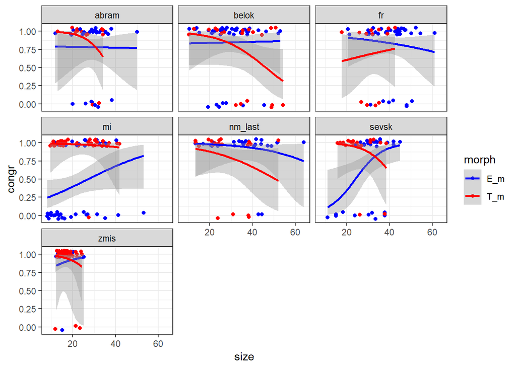

В white-normal. Видим связь – это “chupa”. Опять же вероятность правильного определения ниже у мелких моллюсков E-морфотипа. Но! в случае с популяцией “umba” в отношении E-морфотипа: вероятность правильного определения низка у мелких особей. НО! здесь еще фокус выкидывает Т-морфотип, у которого вероятность правильного определения меньше среди крупных особей (там правда, всего 3 особи, которые оттянули на себя кривую, но все-таки…)

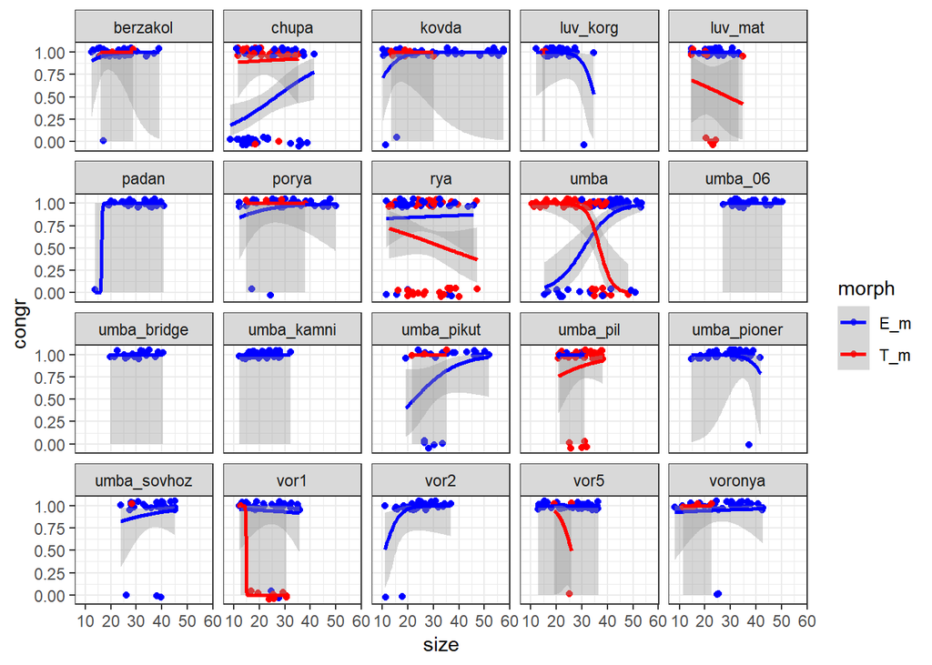

В случае white-fresh. Все ОК!

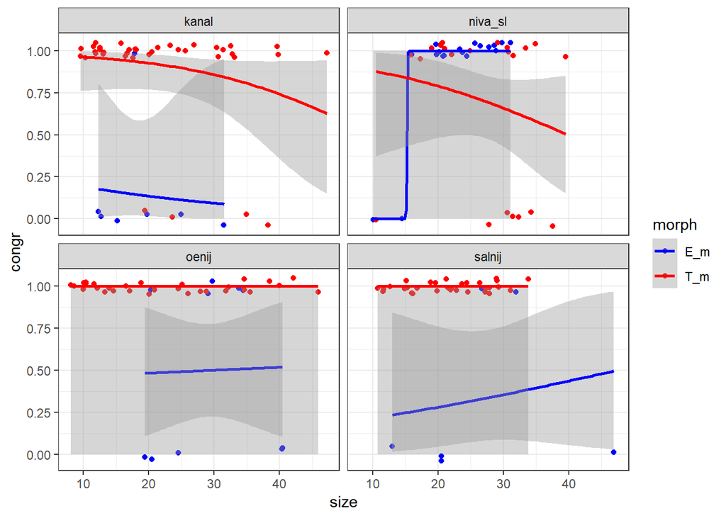

Итого, в 5 случаях из 39 связь с размером как-то видна. С одной стороны, это локальный эффект, который не даст сильного влияния на общую модель (к тому же регрессионные модели, которые мы строим, включают случайные эффекты популяций). О том, что эффект размера слаб, говорит и отсутствие явного паттерна в остатках если их рассматривать в связи с размером (смотри report_VM_4.html). Короче, по сумме доводов считаю, что роль размера в работе морфотипа, как диагностического признака, мала.

Но с другой стороны, как-то странно все это. Почему в ряде случаев, не связанных друг с другом каким-то естественным фактором, появляется какая-то хрень - мелкие моллюски хуже определяются чем крупные. Кроме сбоев в обработке (ошибки в определении генотипов или ошибки в определении морфотипов) есть какие-нибудь еще идеи?